# Risk Factor Analysis

## Outcome Variable

**Outcome Variable:** swasted

## Predictor Variables

**Intervention Variable:** mage

**Adjustment Set:**

- arm
- meducyrs
- feducyrs
- W_mhtcm
- W_mwtkg
- W_mbmi
- single
- delta_meducyrs
- delta_feducyrs
- delta_W_mhtcm
- delta_W_mwtkg
- delta_W_mbmi
- delta_single

## Stratifying Variables

The analysis was stratified on these variable(s):

- agecat
- studyid
- country

## Data Summary

| agecat | studyid | country | mage | swasted | n_cell | n |
| --- | --- | --- | --- | --- | --- | --- |
| Birth | ki0047075b-MAL-ED | BANGLADESH | [20-30) | 0 | 142 | 215 |
| Birth | ki0047075b-MAL-ED | BANGLADESH | [20-30) | 1 | 6 | 215 |
| Birth | ki0047075b-MAL-ED | BANGLADESH | <20 | 0 | 28 | 215 |
| Birth | ki0047075b-MAL-ED | BANGLADESH | <20 | 1 | 0 | 215 |
| Birth | ki0047075b-MAL-ED | BANGLADESH | >=30 | 0 | 37 | 215 |
| Birth | ki0047075b-MAL-ED | BANGLADESH | >=30 | 1 | 2 | 215 |
| Birth | ki0047075b-MAL-ED | BRAZIL | [20-30) | 0 | 39 | 62 |
| Birth | ki0047075b-MAL-ED | BRAZIL | [20-30) | 1 | 0 | 62 |
| Birth | ki0047075b-MAL-ED | BRAZIL | <20 | 0 | 8 | 62 |
| Birth | ki0047075b-MAL-ED | BRAZIL | <20 | 1 | 0 | 62 |
| Birth | ki0047075b-MAL-ED | BRAZIL | >=30 | 0 | 15 | 62 |
| Birth | ki0047075b-MAL-ED | BRAZIL | >=30 | 1 | 0 | 62 |
| Birth | ki0047075b-MAL-ED | INDIA | [20-30) | 0 | 36 | 45 |
| Birth | ki0047075b-MAL-ED | INDIA | [20-30) | 1 | 0 | 45 |
| Birth | ki0047075b-MAL-ED | INDIA | <20 | 0 | 7 | 45 |
| Birth | ki0047075b-MAL-ED | INDIA | <20 | 1 | 0 | 45 |
| Birth | ki0047075b-MAL-ED | INDIA | >=30 | 0 | 2 | 45 |
| Birth | ki0047075b-MAL-ED | INDIA | >=30 | 1 | 0 | 45 |
| Birth | ki0047075b-MAL-ED | NEPAL | [20-30) | 0 | 20 | 26 |
| Birth | ki0047075b-MAL-ED | NEPAL | [20-30) | 1 | 1 | 26 |
| Birth | ki0047075b-MAL-ED | NEPAL | <20 | 0 | 0 | 26 |
| Birth | ki0047075b-MAL-ED | NEPAL | <20 | 1 | 0 | 26 |
| Birth | ki0047075b-MAL-ED | NEPAL | >=30 | 0 | 5 | 26 |
| Birth | ki0047075b-MAL-ED | NEPAL | >=30 | 1 | 0 | 26 |
| Birth | ki0047075b-MAL-ED | PERU | [20-30) | 0 | 113 | 228 |
| Birth | ki0047075b-MAL-ED | PERU | [20-30) | 1 | 0 | 228 |
| Birth | ki0047075b-MAL-ED | PERU | <20 | 0 | 63 | 228 |
| Birth | ki0047075b-MAL-ED | PERU | <20 | 1 | 0 | 228 |
| Birth | ki0047075b-MAL-ED | PERU | >=30 | 0 | 52 | 228 |
| Birth | ki0047075b-MAL-ED | PERU | >=30 | 1 | 0 | 228 |

[output cut: 396 more lines]

The following strata were considered:

- agecat: 24 months, studyid: ki0047075b-MAL-ED, country: BANGLADESH
- agecat: 24 months, studyid: ki0047075b-MAL-ED, country: BRAZIL
- agecat: 24 months, studyid: ki0047075b-MAL-ED, country: INDIA
- agecat: 24 months, studyid: ki0047075b-MAL-ED, country: NEPAL
- agecat: 24 months, studyid: ki0047075b-MAL-ED, country: PERU
- agecat: 24 months, studyid: ki0047075b-MAL-ED, country: SOUTH AFRICA
- agecat: 24 months, studyid: ki0047075b-MAL-ED, country: TANZANIA, UNITED REPUBLIC OF
- agecat: 24 months, studyid: ki1000108-CMC-V-BCS-2002, country: INDIA
- agecat: 24 months, studyid: ki1000108-IRC, country: INDIA
- agecat: 24 months, studyid: ki1000109-EE, country: PAKISTAN
- agecat: 24 months, studyid: ki1017093-NIH-Birth, country: BANGLADESH
- agecat: 24 months, studyid: ki1017093b-PROVIDE, country: BANGLADESH
- agecat: 24 months, studyid: ki1017093c-NIH-Crypto, country: BANGLADESH
- agecat: 24 months, studyid: ki1066203-TanzaniaChild2, country: TANZANIA, UNITED REPUBLIC OF
- agecat: 24 months, studyid: ki1101329-Keneba, country: GAMBIA
- agecat: 24 months, studyid: ki1113344-GMS-Nepal, country: NEPAL
- agecat: 24 months, studyid: ki1119695-PROBIT, country: BELARUS
- agecat: 24 months, studyid: ki1126311-ZVITAMBO, country: ZIMBABWE
- agecat: 24 months, studyid: ki1135781-COHORTS, country: GUATEMALA
- agecat: 24 months, studyid: ki1135781-COHORTS, country: INDIA
- agecat: 24 months, studyid: ki1135781-COHORTS, country: PHILIPPINES
- agecat: 24 months, studyid: ki1148112-LCNI-5, country: MALAWI
- agecat: 24 months, studyid: kiGH5241-JiVitA-3, country: BANGLADESH
- agecat: 6 months, studyid: ki0047075b-MAL-ED, country: BANGLADESH
- agecat: 6 months, studyid: ki0047075b-MAL-ED, country: BRAZIL
- agecat: 6 months, studyid: ki0047075b-MAL-ED, country: INDIA
- agecat: 6 months, studyid: ki0047075b-MAL-ED, country: NEPAL
- agecat: 6 months, studyid: ki0047075b-MAL-ED, country: PERU
- agecat: 6 months, studyid: ki0047075b-MAL-ED, country: SOUTH AFRICA
- agecat: 6 months, studyid: ki0047075b-MAL-ED, country: TANZANIA, UNITED REPUBLIC OF
- agecat: 6 months, studyid: ki1000108-CMC-V-BCS-2002, country: INDIA
- agecat: 6 months, studyid: ki1000108-IRC, country: INDIA
- agecat: 6 months, studyid: ki1000109-EE, country: PAKISTAN
- agecat: 6 months, studyid: ki1000304b-SAS-CompFeed, country: INDIA
- agecat: 6 months, studyid: ki1000304b-SAS-FoodSuppl, country: INDIA
- agecat: 6 months, studyid: ki1017093-NIH-Birth, country: BANGLADESH
- agecat: 6 months, studyid: ki1017093b-PROVIDE, country: BANGLADESH
- agecat: 6 months, studyid: ki1017093c-NIH-Crypto, country: BANGLADESH
- agecat: 6 months, studyid: ki1066203-TanzaniaChild2, country: TANZANIA, UNITED REPUBLIC OF
- agecat: 6 months, studyid: ki1101329-Keneba, country: GAMBIA
- agecat: 6 months, studyid: ki1112895-Guatemala BSC, country: GUATEMALA
- agecat: 6 months, studyid: ki1113344-GMS-Nepal, country: NEPAL
- agecat: 6 months, studyid: ki1119695-PROBIT, country: BELARUS
- agecat: 6 months, studyid: ki1126311-ZVITAMBO, country: ZIMBABWE
- agecat: 6 months, studyid: ki1135781-COHORTS, country: GUATEMALA
- agecat: 6 months, studyid: ki1135781-COHORTS, country: INDIA
- agecat: 6 months, studyid: ki1135781-COHORTS, country: PHILIPPINES
- agecat: 6 months, studyid: ki1148112-LCNI-5, country: MALAWI
- agecat: 6 months, studyid: kiGH5241-JiVitA-3, country: BANGLADESH
- agecat: Birth, studyid: ki0047075b-MAL-ED, country: BANGLADESH
- agecat: Birth, studyid: ki0047075b-MAL-ED, country: BRAZIL
- agecat: Birth, studyid: ki0047075b-MAL-ED, country: INDIA
- agecat: Birth, studyid: ki0047075b-MAL-ED, country: NEPAL
- agecat: Birth, studyid: ki0047075b-MAL-ED, country: PERU
- agecat: Birth, studyid: ki0047075b-MAL-ED, country: SOUTH AFRICA
- agecat: Birth, studyid: ki0047075b-MAL-ED, country: TANZANIA, UNITED REPUBLIC OF
- agecat: Birth, studyid: ki1000108-CMC-V-BCS-2002, country: INDIA
- agecat: Birth, studyid: ki1000108-IRC, country: INDIA
- agecat: Birth, studyid: ki1000109-EE, country: PAKISTAN
- agecat: Birth, studyid: ki1000304b-SAS-CompFeed, country: INDIA
- agecat: Birth, studyid: ki1017093-NIH-Birth, country: BANGLADESH
- agecat: Birth, studyid: ki1017093b-PROVIDE, country: BANGLADESH
- agecat: Birth, studyid: ki1017093c-NIH-Crypto, country: BANGLADESH
- agecat: Birth, studyid: ki1101329-Keneba, country: GAMBIA
- agecat: Birth, studyid: ki1113344-GMS-Nepal, country: NEPAL
- agecat: Birth, studyid: ki1119695-PROBIT, country: BELARUS
- agecat: Birth, studyid: ki1126311-ZVITAMBO, country: ZIMBABWE
- agecat: Birth, studyid: ki1135781-COHORTS, country: GUATEMALA
- agecat: Birth, studyid: ki1135781-COHORTS, country: INDIA
- agecat: Birth, studyid: ki1135781-COHORTS, country: PHILIPPINES
- agecat: Birth, studyid: kiGH5241-JiVitA-3, country: BANGLADESH

### Dropped Strata

Some strata were dropped due to rare outcomes:

- agecat: Birth, studyid: ki0047075b-MAL-ED, country: BANGLADESH
- agecat: Birth, studyid: ki0047075b-MAL-ED, country: BRAZIL
- agecat: Birth, studyid: ki0047075b-MAL-ED, country: INDIA
- agecat: Birth, studyid: ki0047075b-MAL-ED, country: NEPAL
- agecat: Birth, studyid: ki0047075b-MAL-ED, country: PERU
- agecat: Birth, studyid: ki0047075b-MAL-ED, country: SOUTH AFRICA
- agecat: Birth, studyid: ki0047075b-MAL-ED, country: TANZANIA, UNITED REPUBLIC OF
- agecat: Birth, studyid: ki1000108-CMC-V-BCS-2002, country: INDIA
- agecat: Birth, studyid: ki1000108-IRC, country: INDIA
- agecat: Birth, studyid: ki1000109-EE, country: PAKISTAN
- agecat: Birth, studyid: ki1000304b-SAS-CompFeed, country: INDIA
- agecat: Birth, studyid: ki1017093-NIH-Birth, country: BANGLADESH
- agecat: Birth, studyid: ki1017093b-PROVIDE, country: BANGLADESH
- agecat: Birth, studyid: ki1113344-GMS-Nepal, country: NEPAL
- agecat: 6 months, studyid: ki0047075b-MAL-ED, country: BANGLADESH
- agecat: 6 months, studyid: ki0047075b-MAL-ED, country: BRAZIL
- agecat: 6 months, studyid: ki0047075b-MAL-ED, country: INDIA
- agecat: 6 months, studyid: ki0047075b-MAL-ED, country: NEPAL
- agecat: 6 months, studyid: ki0047075b-MAL-ED, country: PERU
- agecat: 6 months, studyid: ki0047075b-MAL-ED, country: SOUTH AFRICA
- agecat: 6 months, studyid: ki0047075b-MAL-ED, country: TANZANIA, UNITED REPUBLIC OF
- agecat: 6 months, studyid: ki1000108-CMC-V-BCS-2002, country: INDIA
- agecat: 6 months, studyid: ki1000108-IRC, country: INDIA
- agecat: 6 months, studyid: ki1000109-EE, country: PAKISTAN
- agecat: 6 months, studyid: ki1000304b-SAS-CompFeed, country: INDIA
- agecat: 6 months, studyid: ki1000304b-SAS-FoodSuppl, country: INDIA
- agecat: 6 months, studyid: ki1017093-NIH-Birth, country: BANGLADESH
- agecat: 6 months, studyid: ki1017093b-PROVIDE, country: BANGLADESH
- agecat: 6 months, studyid: ki1017093c-NIH-Crypto, country: BANGLADESH
- agecat: 6 months, studyid: ki1066203-TanzaniaChild2, country: TANZANIA, UNITED REPUBLIC OF
- agecat: 6 months, studyid: ki1112895-Guatemala BSC, country: GUATEMALA
- agecat: 6 months, studyid: ki1113344-GMS-Nepal, country: NEPAL
- agecat: 6 months, studyid: ki1119695-PROBIT, country: BELARUS
- agecat: 6 months, studyid: ki1135781-COHORTS, country: GUATEMALA
- agecat: 6 months, studyid: ki1148112-LCNI-5, country: MALAWI
- agecat: 24 months, studyid: ki0047075b-MAL-ED, country: BANGLADESH
- agecat: 24 months, studyid: ki0047075b-MAL-ED, country: BRAZIL
- agecat: 24 months, studyid: ki0047075b-MAL-ED, country: INDIA
- agecat: 24 months, studyid: ki0047075b-MAL-ED, country: NEPAL
- agecat: 24 months, studyid: ki0047075b-MAL-ED, country: PERU
- agecat: 24 months, studyid: ki0047075b-MAL-ED, country: SOUTH AFRICA
- agecat: 24 months, studyid: ki0047075b-MAL-ED, country: TANZANIA, UNITED REPUBLIC OF
- agecat: 24 months, studyid: ki1000108-CMC-V-BCS-2002, country: INDIA
- agecat: 24 months, studyid: ki1000108-IRC, country: INDIA
- agecat: 24 months, studyid: ki1000109-EE, country: PAKISTAN
- agecat: 24 months, studyid: ki1017093-NIH-Birth, country: BANGLADESH
- agecat: 24 months, studyid: ki1017093b-PROVIDE, country: BANGLADESH
- agecat: 24 months, studyid: ki1017093c-NIH-Crypto, country: BANGLADESH
- agecat: 24 months, studyid: ki1066203-TanzaniaChild2, country: TANZANIA, UNITED REPUBLIC OF
- agecat: 24 months, studyid: ki1101329-Keneba, country: GAMBIA
- agecat: 24 months, studyid: ki1113344-GMS-Nepal, country: NEPAL
- agecat: 24 months, studyid: ki1119695-PROBIT, country: BELARUS
- agecat: 24 months, studyid: ki1126311-ZVITAMBO, country: ZIMBABWE
- agecat: 24 months, studyid: ki1135781-COHORTS, country: GUATEMALA
- agecat: 24 months, studyid: ki1135781-COHORTS, country: INDIA
- agecat: 24 months, studyid: ki1135781-COHORTS, country: PHILIPPINES
- agecat: 24 months, studyid: ki1148112-LCNI-5, country: MALAWI

## Methods Detail

We’re interested in the causal parameters $E[Y_a]$ for all values of $a \in \mathcal{A}$. These parameters represent the mean outcome if, possibly contrary to fact, we intervened to set all units to have $A=a$. Under the randomization and positivity assumptions, these are identified by the statistical parameters $\psi_a=E_W[E_{Y|A,W}(Y|A=a,W)]$. In addition, we’re interested in the mean of $Y$, $E[Y]$ under no intervention (the observed mean). We will estimate these parameters by using SuperLearner to fit the relevant likelihood factors – $E_{Y|A,W}(Y|A=a,W)$ and $p(A=a|W)$, and then updating our likelihood fit using a joint TMLE.

For unadjusted analyses ($W=\{\}$), initial likelihoods were estimated using Lrnr_glm to estimate the simple $E(Y|A)$ and Lrnr_mean to estimate $p(A)$. For adjusted analyses, a small library containing Lrnr_glmnet, Lrnr_xgboost, and Lrnr_mean was used.

Having estimated these parameters, we will then use the delta method to estimate relative risks and attributable risks relative to a prespecified baseline level of $A$.

# Results Detail

## Results Plots

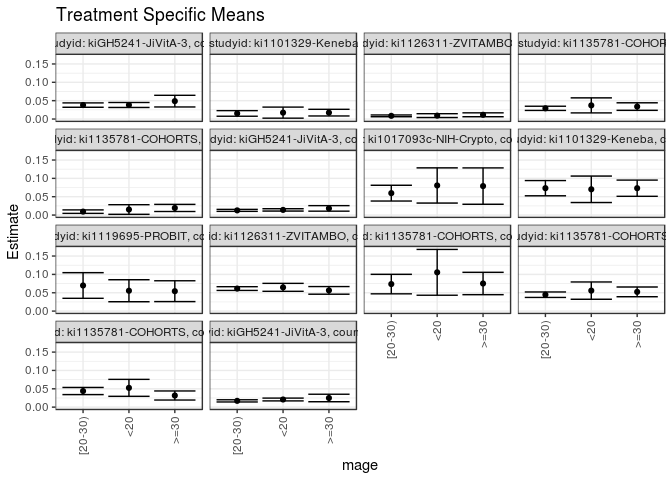

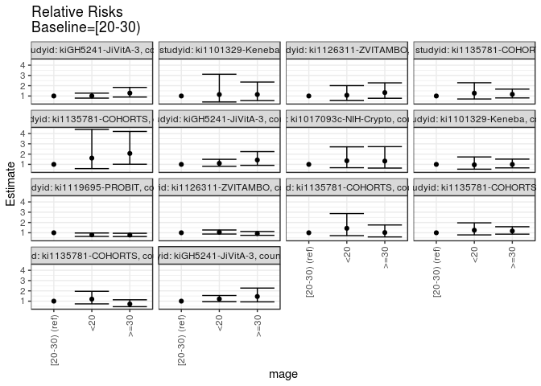

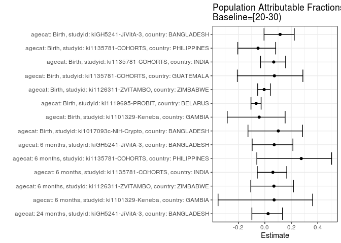

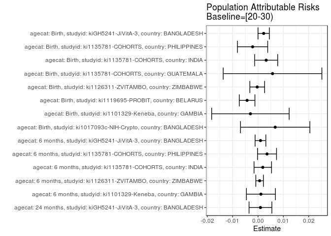

## Results Table

### Parameter: TSM

| agecat | studyid | country | intervention_level | baseline_level | estimate | ci_lower | ci_upper |
| --- | --- | --- | --- | --- | --- | --- | --- |
| Birth | ki1017093c-NIH-Crypto | BANGLADESH | [20-30) | NA | 0.0597015 | 0.0382432 | 0.0811598 |
| Birth | ki1017093c-NIH-Crypto | BANGLADESH | <20 | NA | 0.0806452 | 0.0326856 | 0.1286047 |
| Birth | ki1017093c-NIH-Crypto | BANGLADESH | >=30 | NA | 0.0789474 | 0.0294122 | 0.1284826 |
| Birth | ki1101329-Keneba | GAMBIA | [20-30) | NA | 0.0732553 | 0.0525045 | 0.0940061 |
| Birth | ki1101329-Keneba | GAMBIA | <20 | NA | 0.0702030 | 0.0341386 | 0.1062674 |
| Birth | ki1101329-Keneba | GAMBIA | >=30 | NA | 0.0731954 | 0.0511708 | 0.0952199 |
| Birth | ki1119695-PROBIT | BELARUS | [20-30) | NA | 0.0698093 | 0.0348682 | 0.1047504 |
| Birth | ki1119695-PROBIT | BELARUS | <20 | NA | 0.0555181 | 0.0255517 | 0.0854844 |
| Birth | ki1119695-PROBIT | BELARUS | >=30 | NA | 0.0542392 | 0.0258685 | 0.0826099 |
| Birth | ki1126311-ZVITAMBO | ZIMBABWE | [20-30) | NA | 0.0614057 | 0.0563089 | 0.0665026 |
| Birth | ki1126311-ZVITAMBO | ZIMBABWE | <20 | NA | 0.0647184 | 0.0538936 | 0.0755432 |
| Birth | ki1126311-ZVITAMBO | ZIMBABWE | >=30 | NA | 0.0564505 | 0.0460260 | 0.0668750 |
| Birth | ki1135781-COHORTS | GUATEMALA | [20-30) | NA | 0.0736280 | 0.0470994 | 0.1001567 |
| Birth | ki1135781-COHORTS | GUATEMALA | <20 | NA | 0.1056182 | 0.0431844 | 0.1680520 |
| Birth | ki1135781-COHORTS | GUATEMALA | >=30 | NA | 0.0751962 | 0.0447855 | 0.1056070 |
| Birth | ki1135781-COHORTS | INDIA | [20-30) | NA | 0.0446811 | 0.0372329 | 0.0521293 |
| Birth | ki1135781-COHORTS | INDIA | <20 | NA | 0.0557825 | 0.0322303 | 0.0793348 |
| Birth | ki1135781-COHORTS | INDIA | >=30 | NA | 0.0524228 | 0.0391620 | 0.0656837 |
| Birth | ki1135781-COHORTS | PHILIPPINES | [20-30) | NA | 0.0438791 | 0.0341774 | 0.0535807 |
| Birth | ki1135781-COHORTS | PHILIPPINES | <20 | NA | 0.0525579 | 0.0294438 | 0.0756721 |
| Birth | ki1135781-COHORTS | PHILIPPINES | >=30 | NA | 0.0316837 | 0.0193124 | 0.0440550 |
| Birth | kiGH5241-JiVitA-3 | BANGLADESH | [20-30) | NA | 0.0171437 | 0.0141572 | 0.0201302 |
| Birth | kiGH5241-JiVitA-3 | BANGLADESH | <20 | NA | 0.0208121 | 0.0170256 | 0.0245987 |
| Birth | kiGH5241-JiVitA-3 | BANGLADESH | >=30 | NA | 0.0249197 | 0.0147059 | 0.0351335 |
| 6 months | ki1101329-Keneba | GAMBIA | [20-30) | NA | 0.0151976 | 0.0075635 | 0.0228316 |
| 6 months | ki1101329-Keneba | GAMBIA | <20 | NA | 0.0173611 | 0.0022728 | 0.0324495 |
| 6 months | ki1101329-Keneba | GAMBIA | >=30 | NA | 0.0173913 | 0.0083587 | 0.0264239 |
| 6 months | ki1126311-ZVITAMBO | ZIMBABWE | [20-30) | NA | 0.0086671 | 0.0062482 | 0.0110859 |
| 6 months | ki1126311-ZVITAMBO | ZIMBABWE | <20 | NA | 0.0092776 | 0.0040365 | 0.0145187 |
| 6 months | ki1126311-ZVITAMBO | ZIMBABWE | >=30 | NA | 0.0115399 | 0.0062558 | 0.0168240 |
| 6 months | ki1135781-COHORTS | INDIA | [20-30) | NA | 0.0291493 | 0.0234177 | 0.0348808 |
| 6 months | ki1135781-COHORTS | INDIA | <20 | NA | 0.0371672 | 0.0166850 | 0.0576494 |
| 6 months | ki1135781-COHORTS | INDIA | >=30 | NA | 0.0339288 | 0.0236718 | 0.0441858 |
| 6 months | ki1135781-COHORTS | PHILIPPINES | [20-30) | NA | 0.0093750 | 0.0046521 | 0.0140979 |
| 6 months | ki1135781-COHORTS | PHILIPPINES | <20 | NA | 0.0151057 | 0.0019632 | 0.0282483 |
| 6 months | ki1135781-COHORTS | PHILIPPINES | >=30 | NA | 0.0193548 | 0.0096536 | 0.0290561 |
| 6 months | kiGH5241-JiVitA-3 | BANGLADESH | [20-30) | NA | 0.0127358 | 0.0100127 | 0.0154589 |
| 6 months | kiGH5241-JiVitA-3 | BANGLADESH | <20 | NA | 0.0140562 | 0.0108780 | 0.0172345 |
| 6 months | kiGH5241-JiVitA-3 | BANGLADESH | >=30 | NA | 0.0181483 | 0.0106597 | 0.0256370 |
| 24 months | kiGH5241-JiVitA-3 | BANGLADESH | [20-30) | NA | 0.0379983 | 0.0320150 | 0.0439816 |
| 24 months | kiGH5241-JiVitA-3 | BANGLADESH | <20 | NA | 0.0382497 | 0.0314937 | 0.0450057 |
| 24 months | kiGH5241-JiVitA-3 | BANGLADESH | >=30 | NA | 0.0487650 | 0.0328498 | 0.0646803 |

### Parameter: E(Y)

| agecat | studyid | country | intervention_level | baseline_level | estimate | ci_lower | ci_upper |
| --- | --- | --- | --- | --- | --- | --- | --- |
| Birth | ki1017093c-NIH-Crypto | BANGLADESH | NA | NA | 0.0664781 | 0.0481022 | 0.0848539 |
| Birth | ki1101329-Keneba | GAMBIA | NA | NA | 0.0702592 | 0.0571716 | 0.0833469 |
| Birth | ki1119695-PROBIT | BELARUS | NA | NA | 0.0655098 | 0.0324802 | 0.0985393 |
| Birth | ki1126311-ZVITAMBO | ZIMBABWE | NA | NA | 0.0610977 | 0.0569614 | 0.0652340 |
| Birth | ki1135781-COHORTS | GUATEMALA | NA | NA | 0.0793651 | 0.0600839 | 0.0986462 |
| Birth | ki1135781-COHORTS | INDIA | NA | NA | 0.0479001 | 0.0415930 | 0.0542073 |
| Birth | ki1135781-COHORTS | PHILIPPINES | NA | NA | 0.0417385 | 0.0344572 | 0.0490198 |
| Birth | kiGH5241-JiVitA-3 | BANGLADESH | NA | NA | 0.0193824 | 0.0169738 | 0.0217910 |
| 6 months | ki1101329-Keneba | GAMBIA | NA | NA | 0.0163462 | 0.0108955 | 0.0217968 |
| 6 months | ki1126311-ZVITAMBO | ZIMBABWE | NA | NA | 0.0093062 | 0.0072635 | 0.0113488 |
| 6 months | ki1135781-COHORTS | INDIA | NA | NA | 0.0310394 | 0.0261816 | 0.0358972 |
| 6 months | ki1135781-COHORTS | PHILIPPINES | NA | NA | 0.0129342 | 0.0086762 | 0.0171922 |
| 6 months | kiGH5241-JiVitA-3 | BANGLADESH | NA | NA | 0.0137076 | 0.0116310 | 0.0157842 |
| 24 months | kiGH5241-JiVitA-3 | BANGLADESH | NA | NA | 0.0389625 | 0.0346386 | 0.0432864 |

### Parameter: RR

| agecat | studyid | country | intervention_level | baseline_level | estimate | ci_lower | ci_upper |
| --- | --- | --- | --- | --- | --- | --- | --- |
| Birth | ki1017093c-NIH-Crypto | BANGLADESH | [20-30) | [20-30) | 1.0000000 | 1.0000000 | 1.0000000 |
| Birth | ki1017093c-NIH-Crypto | BANGLADESH | <20 | [20-30) | 1.3508065 | 0.6742361 | 2.7062893 |
| Birth | ki1017093c-NIH-Crypto | BANGLADESH | >=30 | [20-30) | 1.3223684 | 0.6416727 | 2.7251561 |
| Birth | ki1101329-Keneba | GAMBIA | [20-30) | [20-30) | 1.0000000 | 1.0000000 | 1.0000000 |
| Birth | ki1101329-Keneba | GAMBIA | <20 | [20-30) | 0.9583335 | 0.5332082 | 1.7224100 |
| Birth | ki1101329-Keneba | GAMBIA | >=30 | [20-30) | 0.9991813 | 0.6603415 | 1.5118894 |
| Birth | ki1119695-PROBIT | BELARUS | [20-30) | [20-30) | 1.0000000 | 1.0000000 | 1.0000000 |
| Birth | ki1119695-PROBIT | BELARUS | <20 | [20-30) | 0.7952822 | 0.6471944 | 0.9772546 |
| Birth | ki1119695-PROBIT | BELARUS | >=30 | [20-30) | 0.7769627 | 0.6340613 | 0.9520706 |
| Birth | ki1126311-ZVITAMBO | ZIMBABWE | [20-30) | [20-30) | 1.0000000 | 1.0000000 | 1.0000000 |
| Birth | ki1126311-ZVITAMBO | ZIMBABWE | <20 | [20-30) | 1.0539470 | 0.8744730 | 1.2702555 |
| Birth | ki1126311-ZVITAMBO | ZIMBABWE | >=30 | [20-30) | 0.9193034 | 0.7508265 | 1.1255845 |
| Birth | ki1135781-COHORTS | GUATEMALA | [20-30) | [20-30) | 1.0000000 | 1.0000000 | 1.0000000 |
| Birth | ki1135781-COHORTS | GUATEMALA | <20 | [20-30) | 1.4344832 | 0.7179006 | 2.8663327 |
| Birth | ki1135781-COHORTS | GUATEMALA | >=30 | [20-30) | 1.0212989 | 0.5939059 | 1.7562570 |
| Birth | ki1135781-COHORTS | INDIA | [20-30) | [20-30) | 1.0000000 | 1.0000000 | 1.0000000 |
| Birth | ki1135781-COHORTS | INDIA | <20 | [20-30) | 1.2484591 | 0.7929827 | 1.9655537 |
| Birth | ki1135781-COHORTS | INDIA | >=30 | [20-30) | 1.1732668 | 0.8666622 | 1.5883407 |
| Birth | ki1135781-COHORTS | PHILIPPINES | [20-30) | [20-30) | 1.0000000 | 1.0000000 | 1.0000000 |
| Birth | ki1135781-COHORTS | PHILIPPINES | <20 | [20-30) | 1.1977911 | 0.7321035 | 1.9597003 |
| Birth | ki1135781-COHORTS | PHILIPPINES | >=30 | [20-30) | 0.7220683 | 0.4609521 | 1.1310993 |
| Birth | kiGH5241-JiVitA-3 | BANGLADESH | [20-30) | [20-30) | 1.0000000 | 1.0000000 | 1.0000000 |
| Birth | kiGH5241-JiVitA-3 | BANGLADESH | <20 | [20-30) | 1.2139796 | 0.9539030 | 1.5449646 |
| Birth | kiGH5241-JiVitA-3 | BANGLADESH | >=30 | [20-30) | 1.4535763 | 0.9298741 | 2.2722260 |
| 6 months | ki1101329-Keneba | GAMBIA | [20-30) | [20-30) | 1.0000000 | 1.0000000 | 1.0000000 |
| 6 months | ki1101329-Keneba | GAMBIA | <20 | [20-30) | 1.1423611 | 0.4186513 | 3.1171262 |
| 6 months | ki1101329-Keneba | GAMBIA | >=30 | [20-30) | 1.1443478 | 0.5555970 | 2.3569817 |
| 6 months | ki1126311-ZVITAMBO | ZIMBABWE | [20-30) | [20-30) | 1.0000000 | 1.0000000 | 1.0000000 |
| 6 months | ki1126311-ZVITAMBO | ZIMBABWE | <20 | [20-30) | 1.0704488 | 0.5700175 | 2.0102203 |
| 6 months | ki1126311-ZVITAMBO | ZIMBABWE | >=30 | [20-30) | 1.3314647 | 0.7787652 | 2.2764219 |
| 6 months | ki1135781-COHORTS | INDIA | [20-30) | [20-30) | 1.0000000 | 1.0000000 | 1.0000000 |
| 6 months | ki1135781-COHORTS | INDIA | <20 | [20-30) | 1.2750648 | 0.7102129 | 2.2891591 |
| 6 months | ki1135781-COHORTS | INDIA | >=30 | [20-30) | 1.1639669 | 0.8115192 | 1.6694846 |
| 6 months | ki1135781-COHORTS | PHILIPPINES | [20-30) | [20-30) | 1.0000000 | 1.0000000 | 1.0000000 |
| 6 months | ki1135781-COHORTS | PHILIPPINES | <20 | [20-30) | 1.6112790 | 0.5895856 | 4.4034656 |
| 6 months | ki1135781-COHORTS | PHILIPPINES | >=30 | [20-30) | 2.0645161 | 1.0143478 | 4.2019384 |
| 6 months | kiGH5241-JiVitA-3 | BANGLADESH | [20-30) | [20-30) | 1.0000000 | 1.0000000 | 1.0000000 |
| 6 months | kiGH5241-JiVitA-3 | BANGLADESH | <20 | [20-30) | 1.1036761 | 0.8147301 | 1.4950974 |
| 6 months | kiGH5241-JiVitA-3 | BANGLADESH | >=30 | [20-30) | 1.4249809 | 0.9061066 | 2.2409842 |
| 24 months | kiGH5241-JiVitA-3 | BANGLADESH | [20-30) | [20-30) | 1.0000000 | 1.0000000 | 1.0000000 |
| 24 months | kiGH5241-JiVitA-3 | BANGLADESH | <20 | [20-30) | 1.0066162 | 0.7946965 | 1.2750479 |
| 24 months | kiGH5241-JiVitA-3 | BANGLADESH | >=30 | [20-30) | 1.2833480 | 0.8979863 | 1.8340838 |

### Parameter: PAR

| agecat | studyid | country | intervention_level | baseline_level | estimate | ci_lower | ci_upper |
| --- | --- | --- | --- | --- | --- | --- | --- |
| Birth | ki1017093c-NIH-Crypto | BANGLADESH | [20-30) | NA | 0.0067766 | -0.0069064 | 0.0204596 |
| Birth | ki1101329-Keneba | GAMBIA | [20-30) | NA | -0.0029961 | -0.0182847 | 0.0122925 |
| Birth | ki1119695-PROBIT | BELARUS | [20-30) | NA | -0.0042995 | -0.0073815 | -0.0012175 |
| Birth | ki1126311-ZVITAMBO | ZIMBABWE | [20-30) | NA | -0.0003080 | -0.0032166 | 0.0026006 |
| Birth | ki1135781-COHORTS | GUATEMALA | [20-30) | NA | 0.0057370 | -0.0137319 | 0.0252060 |
| Birth | ki1135781-COHORTS | INDIA | [20-30) | NA | 0.0032190 | -0.0013289 | 0.0077670 |
| Birth | ki1135781-COHORTS | PHILIPPINES | [20-30) | NA | -0.0021405 | -0.0081091 | 0.0038280 |
| Birth | kiGH5241-JiVitA-3 | BANGLADESH | [20-30) | NA | 0.0022387 | 0.0000017 | 0.0044757 |
| 6 months | ki1101329-Keneba | GAMBIA | [20-30) | NA | 0.0011486 | -0.0045680 | 0.0068652 |
| 6 months | ki1126311-ZVITAMBO | ZIMBABWE | [20-30) | NA | 0.0006391 | -0.0008579 | 0.0021361 |
| 6 months | ki1135781-COHORTS | INDIA | [20-30) | NA | 0.0018901 | -0.0015720 | 0.0053522 |
| 6 months | ki1135781-COHORTS | PHILIPPINES | [20-30) | NA | 0.0035592 | -0.0001903 | 0.0073087 |
| 6 months | kiGH5241-JiVitA-3 | BANGLADESH | [20-30) | NA | 0.0009718 | -0.0011468 | 0.0030904 |
| 24 months | kiGH5241-JiVitA-3 | BANGLADESH | [20-30) | NA | 0.0009643 | -0.0035385 | 0.0054670 |

### Parameter: PAF

| agecat | studyid | country | intervention_level | baseline_level | estimate | ci_lower | ci_upper |
| --- | --- | --- | --- | --- | --- | --- | --- |
| Birth | ki1017093c-NIH-Crypto | BANGLADESH | [20-30) | NA | 0.1019371 | -0.1272656 | 0.2845369 |
| Birth | ki1101329-Keneba | GAMBIA | [20-30) | NA | -0.0426437 | -0.2841724 | 0.1534580 |
| Birth | ki1119695-PROBIT | BELARUS | [20-30) | NA | -0.0656313 | -0.1046243 | -0.0280148 |
| Birth | ki1126311-ZVITAMBO | ZIMBABWE | [20-30) | NA | -0.0050410 | -0.0537871 | 0.0414502 |
| Birth | ki1135781-COHORTS | GUATEMALA | [20-30) | NA | 0.0722866 | -0.2078982 | 0.2874796 |
| Birth | ki1135781-COHORTS | INDIA | [20-30) | NA | 0.0672029 | -0.0323486 | 0.1571545 |
| Birth | ki1135781-COHORTS | PHILIPPINES | [20-30) | NA | -0.0512841 | -0.2041384 | 0.0821668 |
| Birth | kiGH5241-JiVitA-3 | BANGLADESH | [20-30) | NA | 0.1155022 | -0.0059210 | 0.2222687 |
| 6 months | ki1101329-Keneba | GAMBIA | [20-30) | NA | 0.0702664 | -0.3532073 | 0.3612179 |
| 6 months | ki1126311-ZVITAMBO | ZIMBABWE | [20-30) | NA | 0.0686752 | -0.1061052 | 0.2158378 |
| 6 months | ki1135781-COHORTS | INDIA | [20-30) | NA | 0.0608945 | -0.0571239 | 0.1657371 |
| 6 months | ki1135781-COHORTS | PHILIPPINES | [20-30) | NA | 0.2751786 | -0.0602189 | 0.5044739 |
| 6 months | kiGH5241-JiVitA-3 | BANGLADESH | [20-30) | NA | 0.0708930 | -0.0956984 | 0.2121555 |
| 24 months | kiGH5241-JiVitA-3 | BANGLADESH | [20-30) | NA | 0.0247485 | -0.0977291 | 0.1335608 |